# hcc-singlecell: tumour progenitor-like states and immunosuppressive myeloid cells in human HCC

Antonio Puriel Hernández

05 October 2026

Code: github.com/AntonioPuriel/hcc-singlecell · commit unknown

## Aim

Characterise cellular heterogeneity in human hepatocellular carcinoma (HCC) and infer communication between tumour cells with progenitor/stem-like features and immunosuppressive myeloid cells, to prioritise candidate mediators for experimental validation.

Data: GSE149614 (Lu et al., *Nat Commun* 2022), author count matrix; 10 patients, 21 samples, four sites (tumour, non-tumour liver, portal vein tumour thrombus, lymph-node metastasis). Every step runs in one R `targets` pipeline on an HPC cluster; this page is its last step.

## 1. Data

| check | value |
| --- | --- |
| genes_in_matrix | 25712 |
| cells_in_matrix | 71915 |
| cells_in_metadata | 71915 |
| cells_matched | 71915 |
| cells_only_in_matrix | 0 |
| cells_only_in_metadata | 0 |
| nonzero_fraction | 0.0793 |
| patients | 10 |
| samples | 21 |
| sites | Lymph, Normal, PVTT, Tumor |

| patient | Lymph | Normal | PVTT | Tumor |
| --- | --- | --- | --- | --- |
| HCC01 | 0 | 0 | 0 | 3370 |
| HCC02 | 0 | 0 | 0 | 4100 |
| HCC03 | 0 | 2600 | 0 | 4820 |
| HCC04 | 0 | 3400 | 0 | 3500 |
| HCC05 | 0 | 4660 | 0 | 3350 |
| HCC06 | 0 | 4460 | 0 | 4310 |
| HCC07 | 0 | 3740 | 1830 | 510 |
| HCC08 | 0 | 4800 | 4140 | 4830 |
| HCC09 | 0 | 1960 | 0 | 2820 |
| HCC10 | 2840 | 3070 | 0 | 2800 |

## 2. Quality control

The author matrix was already filtered (mitochondrial fraction capped at 20%). A per-sample upper MAD cut on mitochondrial fraction would have removed far more hepatocytes than T/NK cells (large, mitochondria-rich cells versus small immune cells), so only the lower tail is cut per sample, mitochondrial fraction is capped at 30%, and doublets are called with scDblFinder per sample.

| cell_type | n_cells | median_umi | median_pct_mt | pct_diag_mad_high_umi | pct_diag_mad_high_mt | pct_removed_qc | pct_doublet |
| --- | --- | --- | --- | --- | --- | --- | --- |
| T/NK | 25600 | 2530 | 3.17 | 1.1 | 3 | 0 | 5.1 |
| Hepatocyte | 20800 | 13300 | 4.32 | 1.8 | 13 | 0 | 6.2 |
| Myeloid | 15900 | 5770 | 3.44 | 8.8 | 4.2 | 0 | 5.9 |
| B | 3680 | 7280 | 1.94 | 9.3 | 5.3 | 0.2 | 2.5 |
| Endothelial | 3640 | 5050 | 3.67 | 8.4 | 11.2 | 0 | 6.8 |
| Fibroblast | 2270 | 5880 | 3.42 | 4.2 | 9.1 | 0 | 5.7 |

| sample | patient | site | cells_in | low_umi | low_genes | high_mt | doublets | cells_out | median_umi | median_genes | median_pct_mt |
| --- | --- | --- | --- | --- | --- | --- | --- | --- | --- | --- | --- |
| HCC01T | HCC01 | Tumor | 3370 | 0 | 0 | 0 | 194 | 3170 | 5300 | 1640 | 5.61 |
| HCC02T | HCC02 | Tumor | 4100 | 0 | 4 | 0 | 226 | 3870 | 19500 | 3280 | 2.23 |
| HCC03N | HCC03 | Normal | 2600 | 0 | 0 | 0 | 114 | 2490 | 2660 | 1000 | 4.62 |
| HCC03T | HCC03 | Tumor | 4820 | 0 | 0 | 0 | 321 | 4500 | 7360 | 2000 | 3.73 |
| HCC04N | HCC04 | Normal | 3400 | 0 | 0 | 0 | 181 | 3220 | 2610 | 1050 | 3.24 |
| HCC04T | HCC04 | Tumor | 3500 | 0 | 0 | 0 | 183 | 3320 | 12400 | 2890 | 4.36 |
| HCC05N | HCC05 | Normal | 4660 | 0 | 0 | 0 | 275 | 4380 | 2920 | 1100 | 3.25 |
| HCC05T | HCC05 | Tumor | 3350 | 0 | 0 | 0 | 172 | 3180 | 8650 | 2350 | 4.48 |
| HCC06N | HCC06 | Normal | 4460 | 0 | 0 | 0 | 264 | 4200 | 2650 | 1070 | 3.9 |
| HCC06T | HCC06 | Tumor | 4310 | 0 | 0 | 0 | 280 | 4030 | 4100 | 1420 | 2.85 |
| HCC07N | HCC07 | Normal | 3740 | 0 | 4 | 0 | 199 | 3540 | 3000 | 1210 | 3.53 |
| HCC07P | HCC07 | PVTT | 1830 | 0 | 0 | 0 | 77 | 1750 | 6550 | 1810 | 4.22 |
| HCC07T | HCC07 | Tumor | 510 | 0 | 0 | 0 | 14 | 496 | 2910 | 945 | 4.63 |
| HCC08N | HCC08 | Normal | 4800 | 0 | 0 | 0 | 333 | 4460 | 2450 | 1010 | 3.32 |
| HCC08P | HCC08 | PVTT | 4140 | 0 | 0 | 0 | 199 | 3940 | 13300 | 3330 | 3.52 |
| HCC08T | HCC08 | Tumor | 4830 | 0 | 0 | 0 | 338 | 4500 | 4620 | 1570 | 2.45 |
| HCC09N | HCC09 | Normal | 1960 | 0 | 0 | 0 | 92 | 1870 | 3000 | 1000 | 3.54 |
| HCC09T | HCC09 | Tumor | 2820 | 0 | 0 | 0 | 121 | 2700 | 4820 | 1550 | 3.22 |
| HCC10L | HCC10 | Lymph | 2840 | 0 | 0 | 0 | 131 | 2710 | 5940 | 1720 | 2.48 |
| HCC10N | HCC10 | Normal | 3070 | 0 | 0 | 0 | 165 | 2910 | 1770 | 704 | 2.95 |

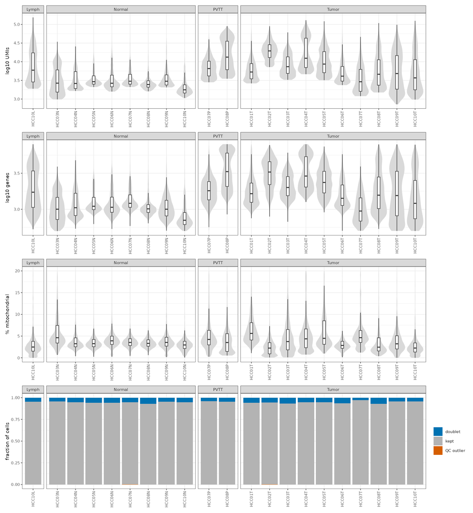

## 3. Integration

LogNormalize, 3,000 HVGs without mitochondrial/ribosomal genes, PCA, Harmony by **patient** (site is the biology and is not regressed out). Mixing is measured with a kNN-based LISI: patient LISI should rise, cell-type LISI should stay near 1.

| embedding | label | n_labels | median_lisi | mean_lisi |
| --- | --- | --- | --- | --- |
| unintegrated | patient | 10 | 1.14 | 1.72 |
| unintegrated | site | 4 | 1 | 1.16 |
| unintegrated | cell_type | 6 | 1 | 1.06 |
| harmony | patient | 10 | 3.04 | 3.1 |
| harmony | site | 4 | 1.07 | 1.31 |
| harmony | cell_type | 6 | 1 | 1.06 |

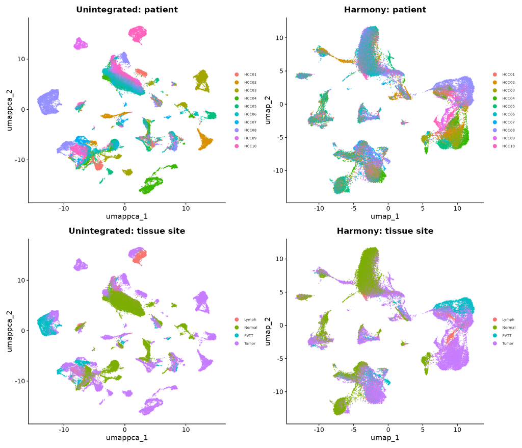

## 4. Annotation and compartments

Leiden clusters annotated with SingleR (HPCA) and canonical markers, compared with the author labels. A guard stops the pipeline if the cluster-to-compartment map no longer matches.

| cluster | n_cells | n_patients | top_patient_frac | sites | singler_majority | singler_frac | author_majority | author_frac |
| --- | --- | --- | --- | --- | --- | --- | --- | --- |
| 0 | 12400 | 10 | 0.21 | Normal,Tumor,Lymph,PVTT | T_cells | 0.86 | T/NK | 0.99 |
| 1 | 6870 | 10 | 0.14 | Tumor,PVTT,Lymph,Normal | Macrophage | 0.79 | Myeloid | 0.99 |
| 2 | 6720 | 9 | 0.24 | Normal,Tumor,Lymph,PVTT | NK_cell | 0.8 | T/NK | 0.99 |
| 3 | 6530 | 8 | 0.36 | Tumor,Lymph,Normal | Hepatocytes | 1 | Hepatocyte | 0.96 |
| 4 | 5250 | 9 | 0.67 | Tumor,PVTT,Lymph,Normal | Hepatocytes | 0.92 | Hepatocyte | 0.95 |
| 5 | 4200 | 10 | 0.16 | Normal,Tumor,PVTT,Lymph | Monocyte | 0.69 | Myeloid | 0.99 |
| 6 | 3580 | 10 | 0.4 | Tumor,PVTT,Lymph,Normal | Hepatocytes | 0.77 | Hepatocyte | 0.92 |
| 7 | 3060 | 10 | 0.28 | Normal,Tumor,Lymph | Macrophage | 0.72 | Myeloid | 0.99 |
| 8 | 2430 | 10 | 0.24 | Tumor,Normal,PVTT,Lymph | Endothelial_cells | 0.77 | Endothelial | 0.91 |
| 9 | 2340 | 10 | 0.49 | Tumor,Normal,Lymph,PVTT | T_cells | 0.92 | T/NK | 0.97 |
| 10 | 2050 | 10 | 0.3 | Tumor,Normal,PVTT,Lymph | Tissue_stem_cells | 0.59 | Fibroblast | 0.99 |
| 11 | 1920 | 10 | 0.4 | Normal,Tumor,Lymph | Hepatocytes | 1 | Hepatocyte | 0.95 |
| 12 | 1500 | 10 | 0.24 | Tumor,PVTT,Normal,Lymph | T_cells | 0.54 | T/NK | 0.75 |
| 13 | 1500 | 8 | 0.41 | Tumor,Lymph,Normal | Hepatocytes | 1 | Hepatocyte | 0.98 |
| 14 | 1350 | 10 | 0.28 | Normal,Tumor,Lymph,PVTT | B_cell | 0.95 | B | 0.96 |
| 15 | 1320 | 10 | 0.31 | Tumor,Normal,PVTT,Lymph | B_cell | 0.45 | B | 0.94 |
| 16 | 1250 | 9 | 0.31 | Normal,Tumor | Endothelial_cells | 0.55 | Endothelial | 0.92 |
| 17 | 988 | 5 | 0.51 | Tumor,Lymph,Normal | Hepatocytes | 1 | Hepatocyte | 0.96 |
| 18 | 820 | 10 | 0.49 | PVTT,Tumor,Normal,Lymph | Macrophage | 0.63 | Myeloid | 0.87 |
| 19 | 662 | 9 | 0.76 | Tumor,Normal | Hepatocytes | 0.62 | B | 0.65 |
| 20 | 577 | 9 | 0.42 | Normal,Tumor | T_cells | 0.54 | T/NK | 0.95 |
| 21 | 367 | 8 | 0.32 | Normal,Tumor,Lymph | Hepatocytes | 0.85 | Hepatocyte | 0.93 |
| 22 | 173 | 10 | 0.24 | Normal,Tumor,PVTT,Lymph | Monocyte | 0.4 | Myeloid | 0.65 |

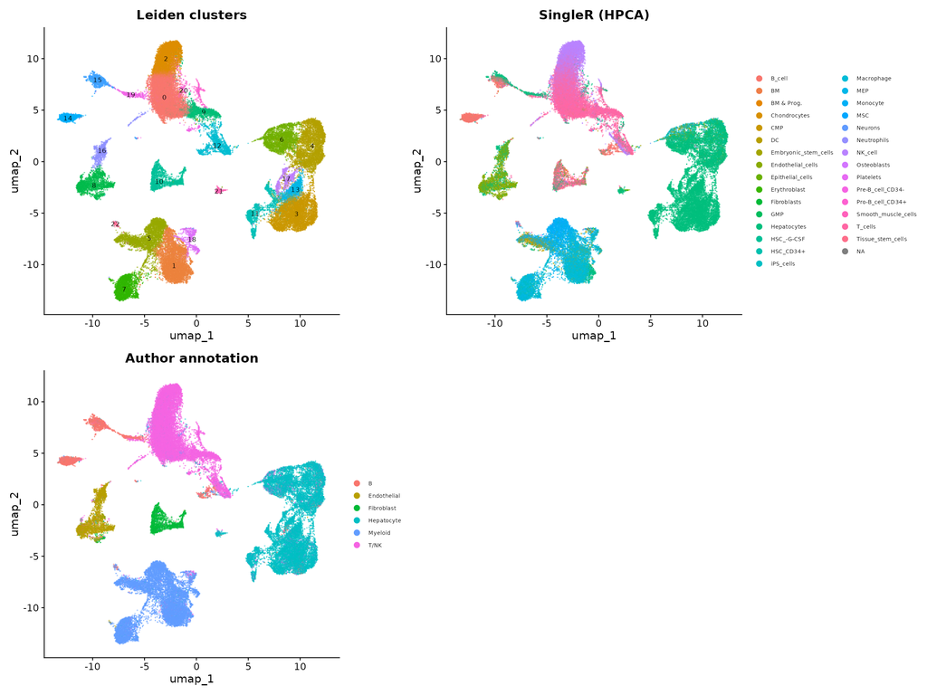

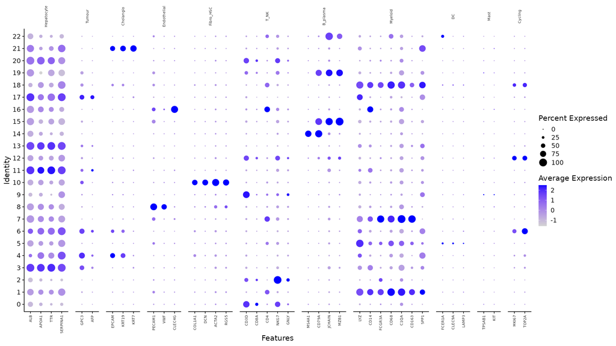

| compartment | n_cells | expected_author_labels | agreement |
| --- | --- | --- | --- |
| T_NK | 23000 | T/NK | 0.973 |
| Myeloid | 15000 | Myeloid | 0.982 |
| B_plasma | 2670 | B | 0.95 |
| Endothelial | 3690 | Endothelial | 0.914 |
| Fibroblast | 2050 | Fibroblast | 0.991 |
| Epithelial | 20100 | Hepatocyte | 0.95 |

| patient | B_plasma | Endothelial | Epithelial | Fibroblast | Flagged | Myeloid | pDC | T_NK |
| --- | --- | --- | --- | --- | --- | --- | --- | --- |
| HCC01 | 6 | 521 | 31 | 175 | 33 | 1420 | 2 | 982 |
| HCC02 | 426 | 14 | 2080 | 12 | 505 | 445 | 4 | 390 |
| HCC03 | 139 | 230 | 4210 | 27 | 214 | 1950 | 9 | 210 |
| HCC04 | 186 | 499 | 2760 | 131 | 40 | 1410 | 10 | 1490 |
| HCC05 | 244 | 893 | 1240 | 148 | 245 | 1760 | 11 | 3030 |
| HCC06 | 594 | 731 | 436 | 613 | 48 | 1660 | 31 | 4110 |
| HCC07 | 343 | 206 | 224 | 114 | 101 | 2160 | 41 | 2600 |
| HCC08 | 161 | 221 | 4950 | 474 | 18 | 1800 | 16 | 5260 |
| HCC09 | 322 | 195 | 1600 | 202 | 24 | 698 | 28 | 1500 |
| HCC10 | 245 | 176 | 2620 | 153 | 11 | 1650 | 21 | 3420 |

## 5. Malignant cells (inferCNV)

inferCNV per patient. The reference combines immune/stromal cells with non-tumour epithelium from the *other* patients (leave-one-patient-out), so lineage-specific expression is not read as copy-number change; thresholds are calibrated on that epithelial reference, and each patient’s own non-tumour epithelium is a negative control.

| patient | site | malignant | non-malignant | unresolved | n_epithelial | pct_malignant |
| --- | --- | --- | --- | --- | --- | --- |
| HCC02 | Tumor | 2070 | 0 | 2 | 2080 | 99.9 |
| HCC03 | Normal | 1 | 813 | 4 | 818 | 0.1 |
| HCC03 | Tumor | 3390 | 0 | 3 | 3400 | 99.9 |
| HCC04 | Normal | 0 | 310 | 10 | 320 | 0 |
| HCC04 | Tumor | 2440 | 1 | 1 | 2440 | 99.9 |
| HCC05 | Normal | 0 | 30 | 4 | 34 | 0 |
| HCC05 | Tumor | 1190 | 11 | 5 | 1200 | 98.7 |
| HCC06 | Normal | 10 | 184 | 12 | 206 | 4.9 |
| HCC06 | Tumor | 227 | 1 | 2 | 230 | 98.7 |
| HCC07 | Normal | 4 | 30 | 0 | 34 | 11.8 |
| HCC07 | PVTT | 128 | 0 | 1 | 129 | 99.2 |
| HCC07 | Tumor | 61 | 0 | 0 | 61 | 100 |
| HCC08 | Normal | 3 | 12 | 4 | 19 | 15.8 |
| HCC08 | PVTT | 3230 | 0 | 0 | 3230 | 100 |
| HCC08 | Tumor | 1690 | 0 | 4 | 1700 | 99.8 |
| HCC09 | Normal | 4 | 124 | 10 | 138 | 2.9 |
| HCC09 | Tumor | 1460 | 0 | 3 | 1460 | 99.8 |
| HCC10 | Lymph | 1450 | 4 | 2 | 1450 | 99.6 |
| HCC10 | Normal | 35 | 27 | 8 | 70 | 50 |
| HCC10 | Tumor | 1080 | 9 | 9 | 1100 | 98.4 |

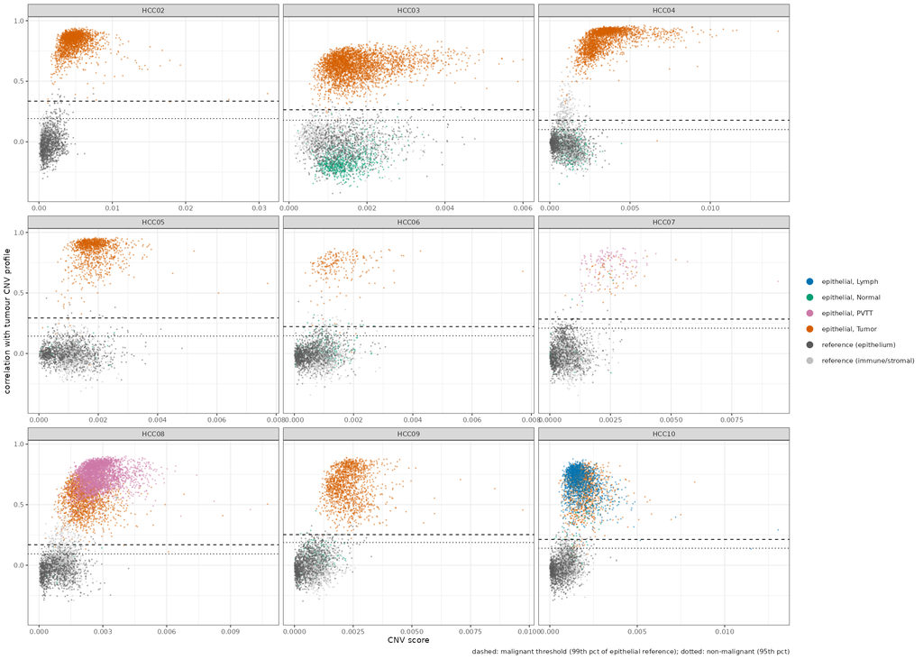

## 6. Myeloid states

Myeloid cells re-analysed on their own (HVGs, PCA, Harmony, Leiden). “Immunosuppressive” is an explicit gene programme (CD274, IL10, SPP1, TREM2, APOE, CD163, VEGFA, …), not an assumed identity. Tumour enrichment is the median over paired patients of log2(tumour fraction / non-tumour fraction).

| state | n_cells | n_patients | pct_tumour_sites | median_log2_tumour_vs_normal | n_paired_patients | mean_suppression_score | top_markers |
| --- | --- | --- | --- | --- | --- | --- | --- |
| 3 | 2000 | 10 | 98.4 | 1.6 | 8 | 0.204 | SPP1, CSTB, LGALS1, S100A10, S100A6, GAPDH, S100A11, ALDOA |
| 2 | 2110 | 10 | 95.7 | 4.6 | 8 | 0.193 | PSAP, APOC1, C1QC, TMEM176B, APOE, LGMN, CTSD, CD63 |
| 0 | 2660 | 10 | 97.3 | 3.84 | 8 | 0.187 | RNASE1, APOE, LGMN, A2M, APOC1, SEPP1, DAB2, GYPC |
| 1 | 2540 | 9 | 3 | -5.84 | 8 | 0.129 | CD5L, MARCO, VCAM1, MS4A6A, CXCL12, CD163, LIPA, CETP |
| 10 | 264 | 4 | 94.7 | 0 | 8 | 0.118 | APOH, TTR, APOA1, MARCO, CD5L, CFD, CST3, CFP |
| 9 | 456 | 10 | 92.5 | 1.94 | 8 | 0.076 | STMN1, H2AFZ, TUBA1B, HMGN2, TUBB, HMGB1, KIAA0101, HMGB2 |
| 7 | 926 | 10 | 52.4 | -1.87 | 8 | -0.029 | HLA-DPB1, HLA-DPA1, RPL26, HLA-DRA, HLA-DRB1, RPS15A, RPL10, CD74 |
| 5 | 1130 | 10 | 87.1 | 2.21 | 8 | -0.049 | HSP90AA1, HSPD1, HSPH1, DNAJB1, HSPA1A, HSPE1, ZFAND2A, FCN1 |
| 11 | 81 | 10 | 69.1 | -0.35 | 8 | -0.053 | CCL5, IL32, NKG7, CD3D, CD3E, TRBC2, GZMA, CD2 |
| 6 | 1070 | 10 | 45.5 | -2.15 | 8 | -0.17 | RPS29, RPS18, RPS6, RPS23, HLA-DPB1, RPL41, RPL4, RPL3 |
| 8 | 479 | 10 | 32.8 | -2.88 | 8 | -0.181 | CLEC9A, SNX3, CPNE3, HLA-DPB1, IDO1, CD74, RPS23, LGALS2 |
| 4 | 1240 | 10 | 23.2 | -3.33 | 8 | -0.216 | FCN1, S100A4, RPS27, RPS9, TIMP1, LST1, S100A6, RPL34 |

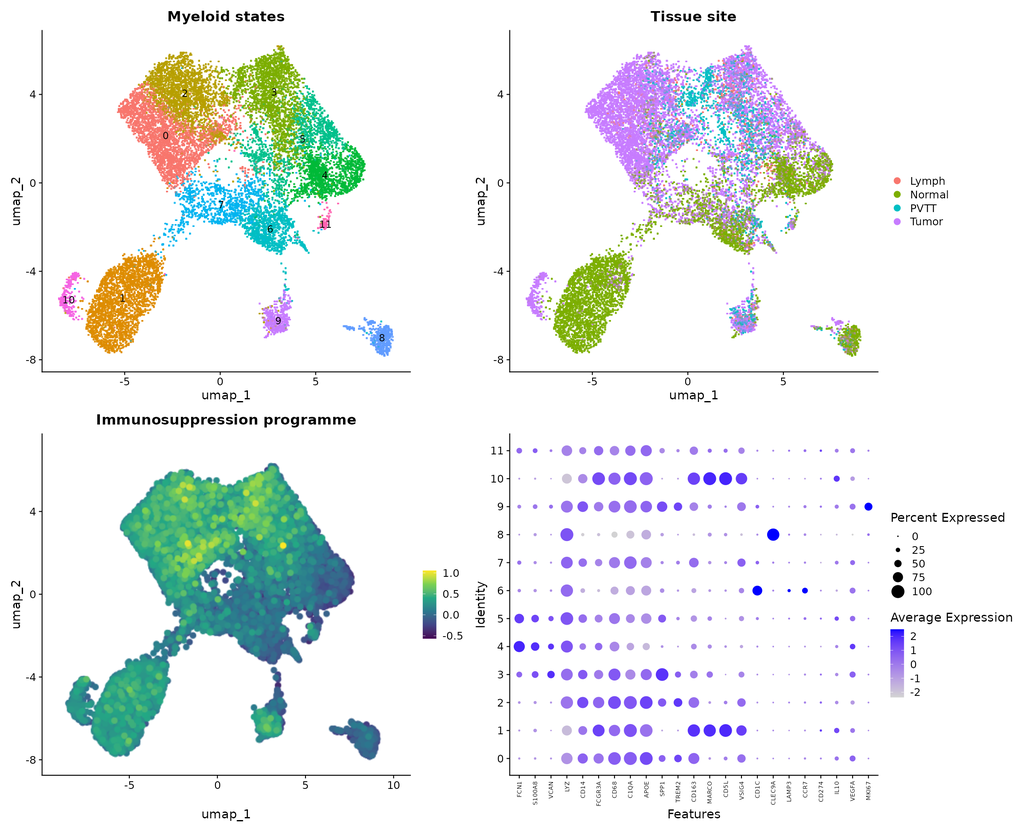

## 7. Progenitor-like tumour cells

Within CNV-confirmed malignant cells, the progenitor-like group is the top quartile per patient of a hepatic progenitor/biliary programme (EPCAM, KRT19, KRT7, SOX9, CD24, PROM1). CytoTRACE2, a trained model of developmental potential that uses the whole transcriptome, is an independent check: the state is described as stem-like only where CytoTRACE2 agrees.

| patient | sites | n_malignant | n_progenitor_like | spearman_prog_vs_cytotrace2 | median_cytotrace2_progenitor | median_cytotrace2_other | wilcox_p | spearman_prog_vs_gene_count |
| --- | --- | --- | --- | --- | --- | --- | --- | --- |
| HCC02 | Tumor | 2070 | 519 | -0.02 | 0.077 | 0.076 | 0.77 | -0.12 |
| HCC03 | Normal,Tumor | 3390 | 849 | -0.02 | 0.022 | 0.02 | 0.079 | -0.08 |
| HCC04 | Tumor | 2440 | 611 | -0.08 | 0.067 | 0.068 | 0.59 | -0.16 |
| HCC05 | Tumor | 1190 | 297 | 0.05 | 0.045 | 0.044 | 0.051 | -0.13 |
| HCC06 | Normal,Tumor | 237 | 60 | 0.33 | 0.08 | 0.069 | 3.6e-05 | -0.06 |
| HCC07 | Normal,PVTT,Tumor | 193 | 49 | 0.12 | 0.117 | 0.113 | 0.00069 | -0.04 |
| HCC08 | Normal,PVTT,Tumor | 4930 | 1230 | 0.1 | 0.257 | 0.243 | 0.0062 | 0.18 |
| HCC09 | Normal,Tumor | 1460 | 365 | 0.21 | 0.246 | 0.233 | 0.066 | -0.13 |
| HCC10 | Lymph,Normal,Tumor | 2560 | 641 | -0.24 | 0.132 | 0.249 | 2.3e-30 | -0.13 |

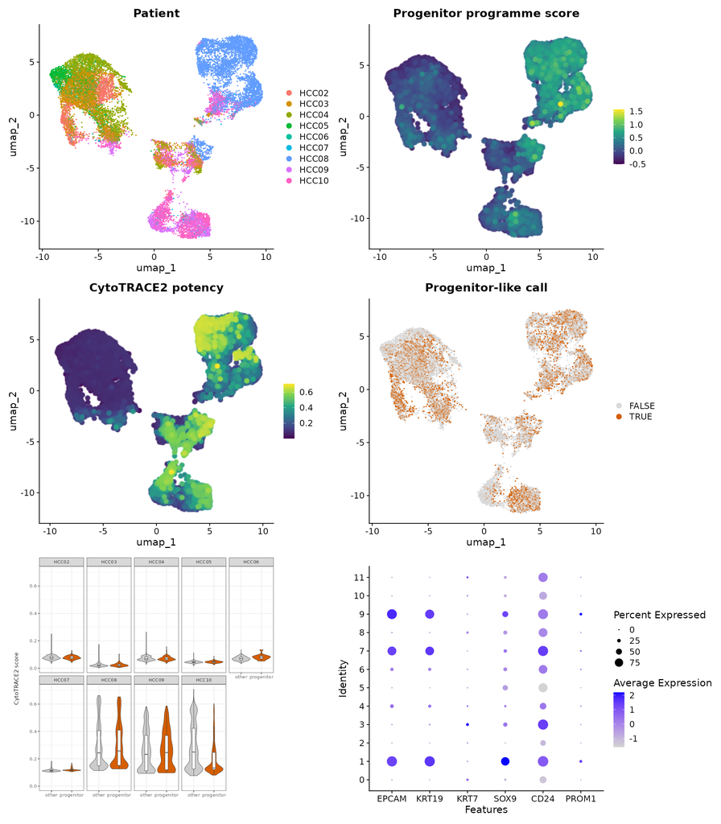

## 8. Pseudobulk differential expression and pathways

Counts summed per sample and group; DESeq2 with `~ patient + group`, so every contrast is within patients. GSEA on Hallmark gene sets ranked by the Wald statistic.

| gene | baseMean | log2FoldChange | padj | n_patients |
| --- | --- | --- | --- | --- |
| SOX9 | 263 | 1.85 | 2.77e-22 | 9 |
| KRT7 | 177 | 2.59 | 1.13e-19 | 9 |
| CD24 | 2740 | 1.65 | 4.52e-16 | 9 |
| CXCL6 | 159 | 1.41 | 0.000146 | 9 |
| CCL28 | 74.1 | 0.636 | 0.00045 | 9 |
| RP1-60O19.1 | 159 | 0.478 | 0.000724 | 9 |
| SPINT1 | 121 | 1.2 | 0.000724 | 9 |
| SOX4 | 1420 | 0.8 | 0.00486 | 9 |
| RAD51AP1 | 87.7 | -0.871 | 0.0063 | 9 |
| CDK1 | 205 | -0.937 | 0.0127 | 9 |
| BHMT | 790 | -0.474 | 0.0153 | 9 |
| SPC25 | 104 | -0.784 | 0.0196 | 9 |
| STX3 | 144 | 0.595 | 0.0196 | 9 |
| GP2 | 333 | 0.95 | 0.0196 | 9 |
| RRM2 | 162 | -1.13 | 0.0203 | 9 |
| SGOL1 | 101 | -0.679 | 0.0309 | 9 |
| SKA3 | 38.3 | -0.723 |  | 9 |
| KRT19 | 404 | 2.73 | 0.0337 | 9 |
| E2F8 | 12.2 | -1.31 |  | 9 |
| HSPA9 | 1290 | -0.264 | 0.0395 | 9 |
| CAPN6 | 18.2 | 1.26 |  | 9 |
| GLYCTK | 477 | -0.365 | 0.048 | 9 |
| VPS29 | 1370 | -0.199 | 0.052 | 9 |
| UBE2T | 257 | -0.591 | 0.0555 | 9 |
| PBK | 121 | -0.928 | 0.0555 | 9 |

| gene | baseMean | log2FoldChange | padj | n_patients |
| --- | --- | --- | --- | --- |
| RNASE1 | 1520 | 4.61 | 5.61e-93 | 8 |
| COLEC12 | 62.9 | 4.78 | 2.89e-16 | 8 |
| RAB13 | 220 | 1.49 | 4.59e-16 | 8 |
| TMEM176A | 533 | 1.98 | 6.52e-16 | 8 |
| AGT | 180 | 3.15 | 6.87e-15 | 8 |
| TMEM176B | 925 | 2.15 | 8.25e-15 | 8 |
| APOC1 | 11700 | 2.28 | 1.94e-14 | 8 |
| GZMB | 102 | -2.66 | 4.48e-14 | 8 |
| MYD88 | 120 | -1.35 | 5.13e-14 | 8 |
| TREM2 | 489 | 3.49 | 1.73e-13 | 8 |
| NKG7 | 231 | -2.13 | 1.97e-13 | 8 |
| FCGR2A | 802 | 1.33 | 2.2e-13 | 8 |
| PLAC8 | 873 | -3.35 | 2.2e-13 | 8 |
| SLC12A5 | 32.1 | 3.64 | 3.78e-13 | 8 |
| C6orf1 | 75.3 | 1.52 | 1.15e-12 | 8 |
| APOA2 | 8340 | 3.11 | 1.27e-12 | 8 |
| NEK6 | 62.1 | 2.17 | 1.61e-12 | 8 |
| NUPR1 | 876 | 3.33 | 2.24e-12 | 8 |
| ARHGAP18 | 262 | 1.53 | 2.75e-12 | 8 |
| LGALS4 | 90.4 | 3.18 | 2.78e-12 | 8 |
| RARRES1 | 80.3 | 3.89 | 2.78e-12 | 8 |
| NDUFA4L2 | 34.2 | 4.64 | 3.02e-12 | 8 |
| SDPR | 124 | -3.17 | 8.82e-12 | 8 |
| RAB42 | 40.8 | 2.96 | 1.01e-11 | 8 |
| FABP5 | 3320 | 1.88 | 2.33e-11 | 8 |

| pathway | NES | padj | size | contrast |
| --- | --- | --- | --- | --- |
| HALLMARK_E2F_TARGETS | -3.79 | 5e-49 | 195 | progenitor vs other |
| HALLMARK_OXIDATIVE_PHOSPHORYLATION | -3.55 | 4.83e-45 | 184 | progenitor vs other |
| HALLMARK_G2M_CHECKPOINT | -3.29 | 7.58e-35 | 188 | progenitor vs other |
| HALLMARK_MYC_TARGETS_V1 | -2.97 | 9.74e-26 | 193 | progenitor vs other |
| HALLMARK_TNFA_SIGNALING_VIA_NFKB | 2.81 | 1.31e-25 | 195 | progenitor vs other |
| HALLMARK_FATTY_ACID_METABOLISM | -2.69 | 1.02e-15 | 147 | progenitor vs other |
| HALLMARK_EPITHELIAL_MESENCHYMAL_TRANSITION | 2.49 | 1.3e-15 | 179 | progenitor vs other |
| HALLMARK_ADIPOGENESIS | -2.47 | 7.76e-14 | 185 | progenitor vs other |
| HALLMARK_HYPOXIA | 2.37 | 2.42e-13 | 188 | progenitor vs other |
| HALLMARK_BILE_ACID_METABOLISM | -2.55 | 5.48e-11 | 105 | progenitor vs other |
| HALLMARK_XENOBIOTIC_METABOLISM | -2.2 | 2.35e-10 | 192 | progenitor vs other |
| HALLMARK_MYC_TARGETS_V2 | -2.64 | 3.86e-10 | 57 | progenitor vs other |
| HALLMARK_DNA_REPAIR | -2.16 | 3.8e-08 | 146 | progenitor vs other |
| HALLMARK_MTORC1_SIGNALING | -1.98 | 8.4e-08 | 195 | progenitor vs other |
| HALLMARK_ESTROGEN_RESPONSE_EARLY | 1.99 | 1.93e-07 | 185 | progenitor vs other |
| HALLMARK_MITOTIC_SPINDLE | -1.89 | 1.15e-06 | 197 | progenitor vs other |
| HALLMARK_APOPTOSIS | 1.97 | 1.85e-06 | 155 | progenitor vs other |
| HALLMARK_APICAL_JUNCTION | 1.92 | 2.19e-06 | 171 | progenitor vs other |
| HALLMARK_INFLAMMATORY_RESPONSE | 1.86 | 5.99e-06 | 177 | progenitor vs other |
| HALLMARK_PEROXISOME | -2.04 | 5.99e-06 | 99 | progenitor vs other |
| HALLMARK_P53_PATHWAY | 1.83 | 8.36e-06 | 185 | progenitor vs other |
| HALLMARK_TGF_BETA_SIGNALING | 2.01 | 5.58e-05 | 53 | progenitor vs other |
| HALLMARK_MYOGENESIS | 1.78 | 0.000108 | 157 | progenitor vs other |
| HALLMARK_KRAS_SIGNALING_UP | 1.69 | 0.000155 | 185 | progenitor vs other |
| HALLMARK_INTERFERON_GAMMA_RESPONSE | 1.7 | 0.000175 | 189 | progenitor vs other |
| HALLMARK_SPERMATOGENESIS | -1.78 | 0.000299 | 95 | progenitor vs other |
| HALLMARK_IL6_JAK_STAT3_SIGNALING | 1.82 | 0.000392 | 81 | progenitor vs other |
| HALLMARK_UV_RESPONSE_DN | 1.7 | 0.000709 | 134 | progenitor vs other |
| HALLMARK_GLYCOLYSIS | 1.49 | 0.00284 | 191 | progenitor vs other |
| HALLMARK_COAGULATION | -1.55 | 0.0042 | 130 | progenitor vs other |

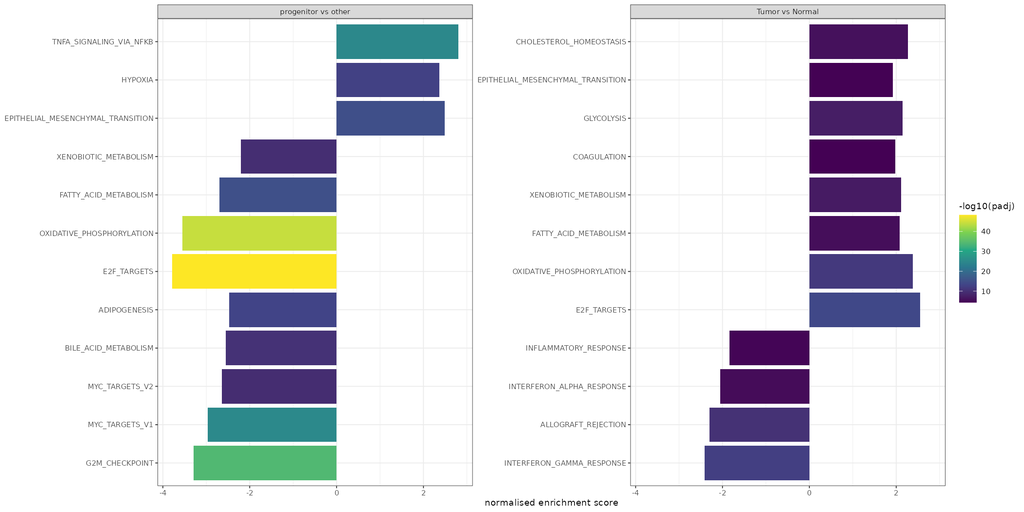

## 9. Communication and candidate mediators

LIANA consensus (NATMI, Connectome, log2FC, SingleCellSignalR) on tumour-site cells. Progenitor-like ↔︎ TAM interactions are ordered by the mean of two ranks: the LIANA aggregate rank and the specificity (how much better the same pair ranks with progenitor-like than with other malignant cells). The order is a list of hypotheses for validation, not a statistical test; genes of the defining programme are flagged.

| direction | source | target | ligand.complex | receptor.complex | aggregate_rank | aggregate_rank_other | specificity | tumour_gene | defining_gene | tumour_gene_log2FC | tumour_gene_padj | priority_score |
| --- | --- | --- | --- | --- | --- | --- | --- | --- | --- | --- | --- | --- |
| prog_to_tam | Progenitor-like tumour | C1Q+APOE+ TAM | CD24 | SIGLEC10 | 0.00251 | 0.137 | 1.74 | CD24 | TRUE | 1.65 | 4.52e-16 | 8 |
| prog_to_tam | Progenitor-like tumour | C1Q+APOE+ TAM | SPON2 | ITGB2 | 0.000844 | 0.00137 | 0.211 | SPON2 | FALSE | 0.192 | 0.998 | 14.5 |
| prog_to_tam | Progenitor-like tumour | SPP1+ TAM | SPON2 | ITGB2 | 0.00287 | 0.0045 | 0.194 | SPON2 | FALSE | 0.192 | 0.998 | 19.5 |
| prog_to_tam | Progenitor-like tumour | APOE+LGMN+ TAM | SPON2 | ITGB2 | 0.00347 | 0.00534 | 0.188 | SPON2 | FALSE | 0.192 | 0.998 | 21.5 |
| prog_to_tam | Progenitor-like tumour | SPP1+ TAM | SERPINE1 | PLAUR | 0.0106 | 0.0191 | 0.258 | SERPINE1 | FALSE | 0.465 | 0.571 | 22 |
| tam_to_prog | C1Q+APOE+ TAM | Progenitor-like tumour | APOE | SCARB1 | 0.0117 | 0.0186 | 0.201 | SCARB1 | FALSE | 0.059 | 0.998 | 29.5 |
| prog_to_tam | Progenitor-like tumour | APOE+LGMN+ TAM | CD59 | STAB1 | 0.0223 | 0.0712 | 0.504 | CD59 | FALSE | 0.281 | 0.24 | 33 |
| tam_to_prog | APOE+LGMN+ TAM | Progenitor-like tumour | APOE | SCARB1 | 0.0132 | 0.0208 | 0.196 | SCARB1 | FALSE | 0.059 | 0.998 | 33 |
| prog_to_tam | Progenitor-like tumour | SPP1+ TAM | CIRBP | TREM1 | 0.00755 | 0.0109 | 0.158 | CIRBP | FALSE | 0.145 | 0.589 | 34 |
| prog_to_tam | Progenitor-like tumour | C1Q+APOE+ TAM | CD59 | STAB1 | 0.0301 | 0.0947 | 0.497 | CD59 | FALSE | 0.281 | 0.24 | 37.5 |
| prog_to_tam | Progenitor-like tumour | C1Q+APOE+ TAM | CD99 | PILRA | 0.0255 | 0.0441 | 0.238 | CD99 | FALSE | 0.00748 | 0.998 | 41.5 |
| tam_to_prog | SPP1+ TAM | Progenitor-like tumour | INHBA | BAMBI | 0.0386 | 0.066 | 0.233 | BAMBI | FALSE | 0.32 | 0.784 | 47 |
| prog_to_tam | Progenitor-like tumour | SPP1+ TAM | CD99 | PILRA | 0.0406 | 0.069 | 0.231 | CD99 | FALSE | 0.00748 | 0.998 | 48.8 |
| tam_to_prog | APOE+LGMN+ TAM | Progenitor-like tumour | CXCL12 | ITGB1 | 0.0107 | 0.014 | 0.116 | ITGB1 | FALSE | 0.149 | 0.773 | 50.5 |
| prog_to_tam | Progenitor-like tumour | APOE+LGMN+ TAM | SERPINE1 | PLAUR | 0.0415 | 0.0682 | 0.216 | SERPINE1 | FALSE | 0.465 | 0.571 | 51 |
| prog_to_tam | Progenitor-like tumour | APOE+LGMN+ TAM | CD99 | PILRA | 0.0433 | 0.0731 | 0.227 | CD99 | FALSE | 0.00748 | 0.998 | 53 |
| prog_to_tam | Progenitor-like tumour | SPP1+ TAM | COL9A3 | CD44 | 0.0198 | 0.0264 | 0.125 | COL9A3 | FALSE | 0.189 | 0.838 | 57.5 |
| prog_to_tam | Progenitor-like tumour | SPP1+ TAM | SPP1 | CD44 | 0.0748 | 0.222 | 0.473 | SPP1 | FALSE | 0.541 | 0.896 | 60 |
| prog_to_tam | Progenitor-like tumour | C1Q+APOE+ TAM | MIF | TNFRSF14 | 0.0406 | 0.0581 | 0.156 | MIF | FALSE | 0.126 | 0.998 | 61.2 |
| tam_to_prog | C1Q+APOE+ TAM | Progenitor-like tumour | APOE | LSR | 0.0136 | 0.0169 | 0.0952 | LSR | FALSE | 0.383 | 0.589 | 62 |
| prog_to_tam | Progenitor-like tumour | APOE+LGMN+ TAM | TFF2 | CXCR4 | 0.0367 | 0.0502 | 0.136 | TFF2 | FALSE | 0.53 | 0.36 | 64 |
| tam_to_prog | C1Q+APOE+ TAM | Progenitor-like tumour | CXCL12 | ITGB1 | 0.0251 | 0.033 | 0.119 | ITGB1 | FALSE | 0.149 | 0.773 | 64 |
| tam_to_prog | APOE+LGMN+ TAM | Progenitor-like tumour | APOE | LSR | 0.0153 | 0.019 | 0.0942 | LSR | FALSE | 0.383 | 0.589 | 64.5 |
| prog_to_tam | Progenitor-like tumour | APOE+LGMN+ TAM | ANXA2 | TLR2 | 0.0321 | 0.0431 | 0.128 | ANXA2 | FALSE | 0.319 | 0.161 | 66.5 |
| prog_to_tam | Progenitor-like tumour | APOE+LGMN+ TAM | GAL | HLA-DPA1 | 0.00869 | 0.0102 | 0.0703 | GAL | FALSE | 0.325 | 0.986 | 75.5 |

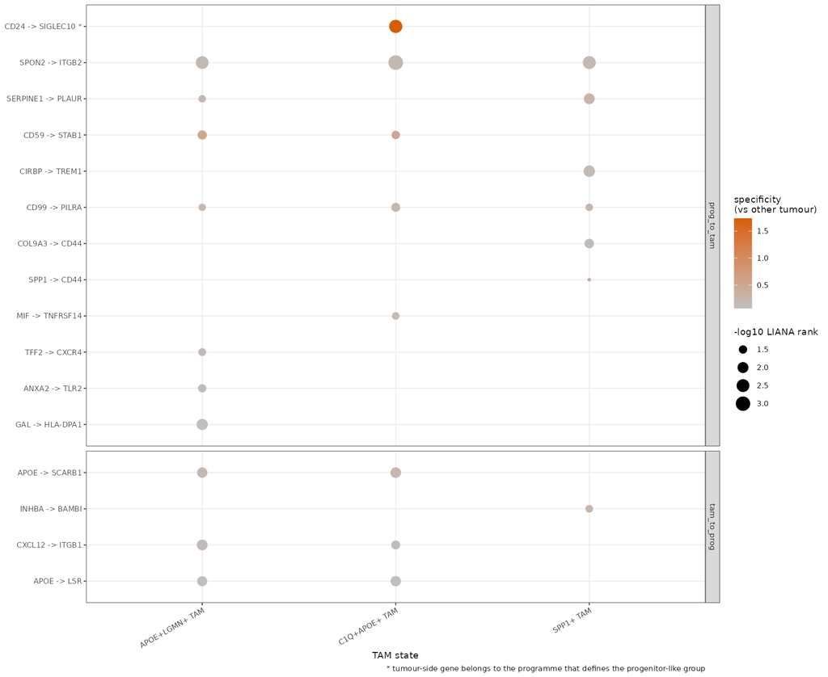

## 10. Myeloid trajectories

Slingshot on the myeloid Harmony embedding, rooted in classical monocytes, restricted to states that can derive from monocytes (Kupffer cells, dendritic cells, the stress-signature state and artefacts excluded). Pseudotime orders cells by similarity and does not prove differentiation. Gene–pseudotime correlations are recomputed per patient and reported with the number of patients that agree on the sign.

| lineage | path | n_cells | pct_tumour_sites_first_decile | pct_tumour_sites_last_decile | n_patients_tested | median_rho_suppression | n_patients_rho_positive |
| --- | --- | --- | --- | --- | --- | --- | --- |
| lineage1 | Classical monocyte -> SPP1+ TAM -> C1Q+APOE+ TAM -> APOE+LGMN+ TAM | 8010 | 18.6 | 95.4 | 10 | 0.34 | 9 |

| lineage | gene | rho | n_patients | n_patients_same_sign | direction |
| --- | --- | --- | --- | --- | --- |
| lineage1 | SEPP1 | 0.735 | 10 | 10 | increases |
| lineage1 | C1QB | 0.708 | 10 | 10 | increases |
| lineage1 | C1QA | 0.707 | 10 | 10 | increases |
| lineage1 | SLC40A1 | 0.702 | 10 | 10 | increases |
| lineage1 | C1QC | 0.684 | 10 | 10 | increases |
| lineage1 | FOLR2 | 0.638 | 10 | 10 | increases |
| lineage1 | LGMN | 0.634 | 10 | 10 | increases |
| lineage1 | CD74 | 0.618 | 10 | 10 | increases |
| lineage1 | DAB2 | 0.604 | 10 | 10 | increases |
| lineage1 | A2M | 0.584 | 10 | 10 | increases |
| lineage1 | APOE | 0.58 | 10 | 10 | increases |
| lineage1 | GPR34 | 0.574 | 10 | 10 | increases |
| lineage1 | HLA-DPB1 | 0.558 | 10 | 9 | increases |
| lineage1 | LIPA | 0.54 | 10 | 10 | increases |
| lineage1 | HLA-DPA1 | 0.533 | 10 | 9 | increases |
| lineage1 | MS4A4A | 0.509 | 10 | 10 | increases |
| lineage1 | MS4A6A | 0.493 | 10 | 10 | increases |
| lineage1 | PLD3 | 0.491 | 10 | 10 | increases |
| lineage1 | HLA-DRA | 0.49 | 10 | 9 | increases |
| lineage1 | FCGRT | 0.487 | 10 | 10 | increases |
| lineage1 | IGF1 | 0.476 | 10 | 10 | increases |
| lineage1 | PDK4 | 0.468 | 10 | 10 | increases |
| lineage1 | HLA-DQA1 | 0.468 | 10 | 10 | increases |
| lineage1 | APOC1 | 0.467 | 10 | 10 | increases |
| lineage1 | CPM | 0.466 | 10 | 10 | increases |
| lineage1 | JUN | 0.458 | 10 | 10 | increases |
| lineage1 | RHOB | 0.458 | 10 | 10 | increases |
| lineage1 | RNASE1 | 0.455 | 10 | 9 | increases |
| lineage1 | CREG1 | 0.445 | 10 | 10 | increases |
| lineage1 | GYPC | 0.443 | 10 | 10 | increases |

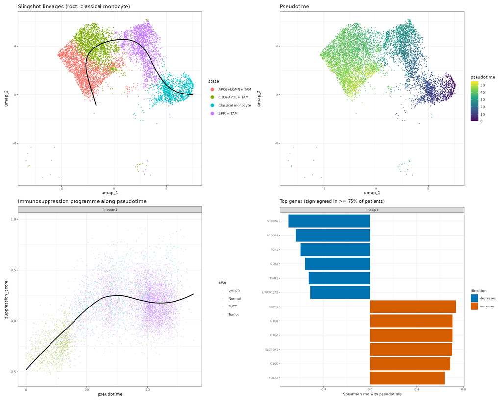

## Limitations

- One public cohort (10 patients); paired tumour/non-tumour material for 8 patients, so site comparisons rest on few replicates.
- No FASTQ: the author matrix and its filtering are taken as given.
- Communication is inferred from expression of ligands and receptors, without spatial information; the next step is to map this reference onto public Xenium/Visium data and quantify colocalisation.
- Pseudotime and CytoTRACE2 are computational orderings, not lineage tracing.

## Reproducibility

R: R version 4.5.3 (2026-03-11)

| package | version |
| --- | --- |
| Seurat | 5.5.1 |
| harmony | 2.0.5 |
| scDblFinder | 1.24.10 |
| SingleR | 2.12.0 |
| infercnv | 1.26.0 |
| DESeq2 | 1.50.2 |
| fgsea | 1.36.2 |
| liana | 0.1.14 |
| slingshot | 2.18.0 |
| CytoTRACE2 | 1.1.0 |
| targets | 1.12.0 |